# ch14 Pipe

saeramlee

2020 10 8

https://gomguard.tistory.com/243 파이프의 종류 4가지

```
%>% (파이프)
%T% (티 파이프)
%<>% (병합 파이프)
%$% (노출 파이프)
```

# 14.1 들어가기

파이프는 일련의 작업을 명확하게 표현할 수 있는 강력한 도구이다. 지금까지 파이프가 어떻게 작동하는지, 또 어떤 대안이 있는지 모른 채 사용했다. 파이프를 자세히 살펴보고, 파이프의 대안, 파이프를 사용하지 말아야 할 경우, 유용한 관련도구에 대해 배워보자.

## 14.1.1 준비하기

파이프 **%>%**는 스테판 밀턴 배치(Stefan Milton Bache)의 **magrittr**패키지에서 가져온 것이다. tibyverse패키지는 자동으로 **%>%**를 로드하므로 보통 명시적으로 로드하지 않는다. 그러나 여기서 우리는 파이프에 집중하며 다른 패키지를 로드하지 않을 것이므로 명시적으로 **magrittr**를 로드한다.

```
install.packages("magrittr")
```

```r
library(magrittr)
```

# 14.2 파이프 대안

파이프의 요점은 읽고 쉽고 이해하기 쉽고 코드를 작성하도록 돕는 것이다. 왜 파이프가 유용한지를 보기 위해 동일한 코드를 여러 가지 방법을 살펴보겠다. 코드를 이용하여 **foo foo** 라는 이름의 작은토끼에 관해 이야기해보자.

> 작은 토끼 Foo Foo,  
> 숩속으로 뛰어서,  
> 들쥐들을 뽑아서,  
> 머리를 꽁꽁치네

율동이 있는 동시이다.

**작은 토끼 Foo Foo**를 표현할 객체를 정의해 보자.

```
foo_foo <- little_bunny()
```

이제 각 핵심 동사에 대해 핵심 함수 hop(), scoop() 및 bop()을 사용하자. 앞의객체에 동사들을 써서 코드로 이야기하는 방법은 (적어도) 네 가지이다.

1. 각 중간 단계마다 새 객체로 저장하기
2. 원본 객체를 여러 번 덮어쓰기
3. 함수 작성하기
4. 파이프 사용하기

## 14.2.1 중간 단계 이용

가장 간단한 방법은 각 단계를 새로운 객체로 저장하는 것이다.

```
foo_foo_1 <- hop(foo_foo, through = forest)
foo_foo_2 <- scoop(foo_foo_1, up = field_mice)
foo_foo_3 <- bop(foo_foo_2, on = head)
```

이 방식의 주요 단점은 각 중간 요소의 이름을 지정해야 한다는 것이다. 자연스러운 이름들이 있다면 이 방법은 나쁘지 않으며 오히려 그렇게 해야한다. 그러나 이 예제에서 보는 것처럼 자연스러운 이름이 없는 경우가 많으며 숫자 접미사를 추가하여 이름을 고유하게 만들게 된다. 이렇게 하면 두 가지 문제가 발생한다.

1. 중요하지 않은 이름들 때문에 코드가 복잡해진다.
2. 각 줄마다 접미사를 신중하게 늘려야 한다.

이러한 방법을 쓰면 많은 데이터 사본이 만들어지면서, 많은 양의 메모리가 필요할 것이라고 우려하는 사람이 있을지 모르겠다. 놀랍게도 이것은 사실이 아니다. 우선 메모리에 대해 사전에 걱정하는 데 시간을 쓰는 것은 바랍직한 방법이 아니다. 사전이 아니라, 문제가 되면 (즉, 메모리가 부족한 경우)그때 걱정하라. 둘째, R은 바보가 아니며 가능한 경우 데이터프레임끼리 열을 공유한다. ggplot2::diamonds에 새 열을 추가하는 실체 데이터 조작 파이프 라인을 살펴보자.

```
diamonds <- ggplot2::diamonds
diamonds2 <- diamonds %>%
  dplyr::mutate(price_per_carat = price / carat)
```

```
pryr::object_size(diamonds)
#> 3.46 MB
pryr::object_size(diamonds2)
#> 3.89 MB
pryr::object_size(diamonds, diamonds2)
#> 3.89 MB
```

pryr::object_size()는 인수 전체가 차지하는 메모리를 제공한다.

- diamond는 3.46MB를 차지한다.
- diamond2는 3.89MB를 차지한다.
- diamdod와 diamond2는 총 3.89MB를 차지한다!

어떻게 된 것일까? diamonds2는 diamond와 열 10개를 공유한다. 데이터를 모두 복제할 필요는 없고 두 개의 데이터프레임은 공유하는 변수가 있다. 이러한 변수는 사용자가 수정하는 경우에만 복사된다. 다음 예제에서는 diamond$carat값 하나를 수정한다. 즉, 두 데이터프레임은 carat변수를 더 이상 공유할 수 없으며 사본이 만들어져야 한다.

```
diamonds$carat[1] <- NA
pryr::object_size(diamonds)
#> 3.64 MB
pryr::object_size(diamonds2)
#> 3.89 MB
pryr::object_size(diamobds, diamonds2)
#> 4.32 MB
```

(여기서는 내장함수 object.size()가 아닌 pryr::object_size()를 사용했다. objecr.size()는 객체 여러개를 공유하는 데이터의 크기를 계산할 수 없다.)

## 14.2.2 원본 덮어쓰기

각 단계에서 중간 개체를 생성하는 대신 원본 객체를 덮어쓸 수도 있다.

```
foo_foo <- hop(foo_foo, through = forest)
foo_foo <- scoop(foo_foo, up = field_mice)
foo_foo <- dop(foo_foo, on = head)
```

이 방법은 타이핑이 줄어들어(그리고 생각할 필요가 줄어들아), 실수할 가능성도 줄어든다. 그러나 두 가지 문제가 있다.

1. 디버깅이 고통스럽다. 실수하면 처음부터 전체 파이프라인을 다시 실행해야 한다.
2. 변환되는 객체가 반복되어서 (위에서 **foo_foo**를 6번 썼다!), 각 행에서 정작 무엇이 변경되는지 알아보기 어렵다.

## 14.2.3 함수 작성

또 다른 접근법은 할당을 하지 않고, 함수 호출을 함께 묶는 것이다.

```
bop(
  scoop(
    hop(foo_foo, through = forest),
    up = field_mice
  ),
  on = head
)
```

여기서 단점은 오른쪽에서 왼쪽으로, 안쪽부터 읽어야 한다는 것과, 인수가 너무 멀리 떨어지게 된다는 것이다 (유창한 말로는 대그우드(Dagwood)센드위치 문제 라고 한다). 요약하면 이런코드는 알아보기 어렵다. *https://en.wikipedia.org/wiki/Dagwood_sandwich

## 14.2.4 파이프 사용

마지막으로 파이프를 사용할 수 있다.

```
foo_foo %>%
hop(through = forest) %>%
scoop(up = field_mice)%>%
bop(on = head)
```

이 방법은 명사가 아닌 동사에 초점을 맞춥니다. 일련의 명령형처럼 읽을 수 있다. Foo Foo는 깡총뛰고(hop), 그 다음 뽑고(scoop), 콩 쳐라(bop). 단점은 물론 파이프에 익숙해져야 한다는 것이다. 전에 %>%를 본 적이 없다면 이 코드가 무엇을 하는지 전혀 알 수 없다. 다행히 대부분의 사람들은 이 방법을 빨리 이해하므로 파이프에 익숙하지 않은 다른 사람들과 코드를 공유할 때도 쉽게 가르칠 수 있다.

파이프는 ’어휘 변환 (lexical transformation)’을 수행하여 작동한다. 즉, 안 보이는 곳에서 **magrittr**는 파이프로 된 코드를, 중간 객체를 덮어 쓰는 형식으로 다시 어셈블한다. 앞과 같은 파이프를 실행하면 **magrittr**는 다음과 같이 처리한다.

```
my_pipe <- function(.){
. <- hop(., through = forest)
. <- scoop(., up = fiedmice)
bop(., on = head)
}
my_pipe(foo_foo)
```

이는 파이프가 다음과 같은 두 가지 종류의 함수에 대해 작동하지 않는다는 것을 의미한다.

- 현재 환경을 사용하는 함수. 예를 들어 assign()은 현재 환경에서, 주어진 이름을 갖는 새로운 변수를 생성한다.

```r
assign("x", 10)
x
```

```
## [1] 10
```

```r
"x" %>% assign(100)
x
```

```
## [1] 10
```

assign은 %>%이 사용하는 임시 환경에 할당하므로, 파이프와 함께 assign을 사용하면 자가동하지 않는다.  
그래도 assign을 파이프와 함께 꼭 사용하고 싶다면, 환경에 대해 명시적이어야 한다.

```r
env <- environment()
"x" %>% assign(100, envir = env)
x
```

```
## [1] 100
```

이와 같은 문제가 생기는 함수에는 get()과 load()등이 있다.

2. 지연 계산법(lazy evaluation)을 사용하는 함수. R에서 함수 인수 계산은 함수 호출 전이 아닌, 함수가 인수를 사용할 때 이루어진다. 파이프는 각 요소를 차례로 계산하므로 이 동작에 의존할 수 없다.

이것이 문제가 되는 곳 중 하나는 오류를 캡쳐하고 처리하는 tryCatch()이다.

```r
tryCatch(stop("!"), error = function(e) "An error")
```

```
## [1] "An error"
```

```r
stop("!") %>%
  tryCatch(error = function(e) "An error")

Error in eval(lhs, parent, parent) : !
```

?try  
?tryCatch

try(try는 선언된 내부 코드중 Error가 있을 경우 이를 그냥 skip)  
tryCatch(예외처리, Error가 발생했더라도 후속 조치)

즉, 이 함수들은 요류를 다루기 위한 함수들입니다.

베이스R의 try(), suppressMessges(), suppressWarnings()등, 비교적 광범위한 함수들이 이러한 동작을 한다.

# 14.3 파이프를 사용하지 말아야 할 경우

- 파이프 길이가 약 10단계보다 긴 경우이다. 이때는 의미 있는 이름을 가진 중간 객체를 만들라. 중간 결과를 더 쉽게 확인할 수 있기 때문에 디 버깅이 쉬워지고, 변수 이름이 의사소통을 도와주기 때문에 코드를 더 쉽게 이해할 수 있다.
- 다중 입력 또는 출력인 경우이다. 주 객체 하나가 변환되는 것이 아니라, 두 개 이상의 객체가 함께 조합되는 경우에는 파이프를 사용하지 않는다.
- 복잡한 종속 구조가 있는 유형 그래프(directed graph)을 고려하는 경우이다. 파이프는 근본적으로 선형이며 이를 이용하여 복잡한 관계를 표현하며 일반적으로 코드가 혼란스러워진다.

# 14.4 magrittr의 기타 도구

tidyverse 의 모든 패키지는 자동으로 %>% 를 사용 가능하게 하므로 보통 **magrittr** 을 명시적으로 로드할 필요가 없다.  
그러나 **magrittr** 안에는 사용해볼 만한 유용한 도구들이 더 있다.

- 복잡한 파이프를 사용할 때, 부수효과(side effect)가 있는 함수들을 활용하는 것이 유용할 경우가 있다. 이러한 함수는 대부분 반환하지 않고 파이프를 실질적으로 종류시킨다.

문제를 해결하려면 ’티’파이프를 사용하면 된다. **%T>%**는 오른쪽 대신 왼쪽을 반환한다는 점을 제외하고 **%>%**처럼 작동한다. 문제 그대로 T자 모양의 파이프이기때문에 ’티’라고 불린다.

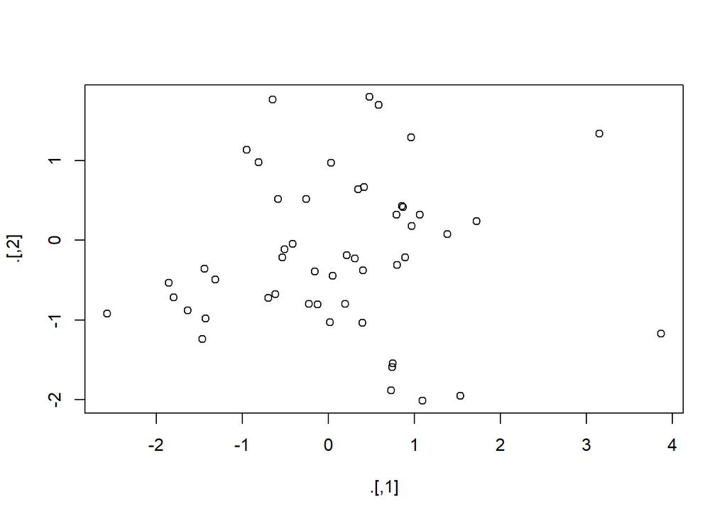

```r
rnorm(100) %>%
  matrix(ncol = 2) %>%
  plot() %>%
  str()
```

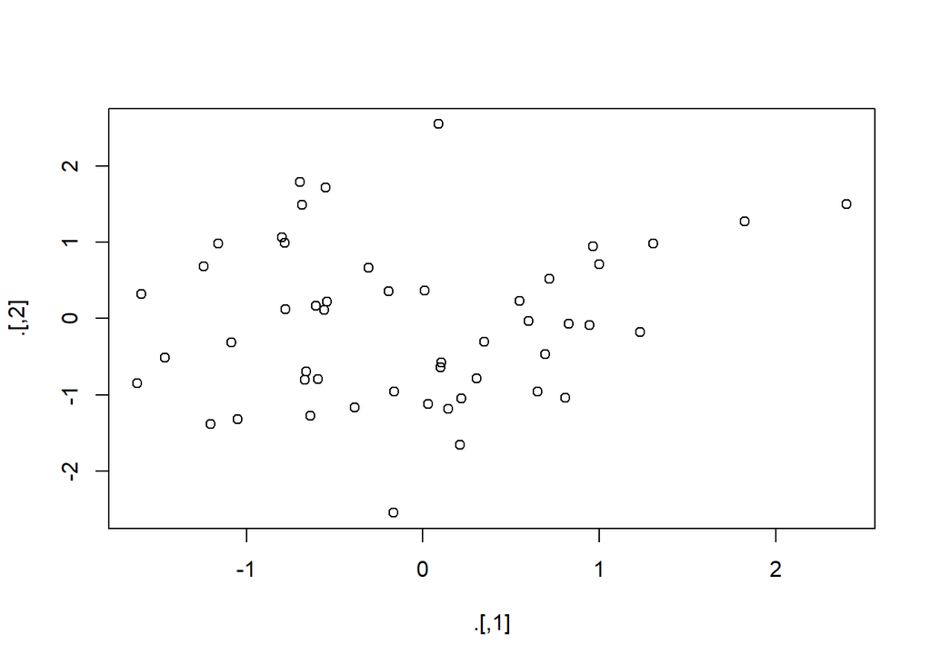

```
##  num [1:50, 1:2] 0.217 0.716 -0.785 0.651 0.346 ...
```

```r
rnorm(100) %>%
  matrix(ncol = 2) %T>%
  plot() %>%
  str()
```

-데이터프레임 기반 API가 없는 함수로 작업하는 경우 (즉, 데이터프레임이 아닌 개별 백터를 전달하고, 표현식을 데이터 프레임 컨텍스트에서 평가할 경우)**%$%** 이 유용하다. 데이터프레임의 변수를 명시적으로 참조할 수 있도록 변수를 추출한다. 이 방법은 베이스R함수 여러개로 작업할 때 유용하다.

```r
mtcars %$%
  cor(disp, mpg)
```

```
## [1] -0.8475514
```

-할당의 경우 magrittr은 %<>% 연산자를 제공하므로 다음과 같은 코드를 대체할 수 있다.

```r
mtcars <- mtcars %>%
  transform(cyl = cyl * 2)
```

위의 코드를 다음과 대체

```r
mtcars %<>% transform(cyl = cyl * 2)
```

https://www.datacamp.com/community/tutorials/pipe-r-tutorial